# Meta Analysis MG: USmerged,Itals,UKBB (imputed hg38)

# Overall MG

**Start date:** 03-30-2021

**End date:** 03-30-2021

**Analysed by:** Ruth Chia

**Working directory:** `/data/NDRS_LNG/MyastheniaGravis/updated.April2020/MetaAnalysis.hg38.ByCohort.rerun/USmerged.Itals.UKBB.hg38`

# Table of Contents

## Summary stats file needed

1. to subset from MG.USmerged: `/data/NDRS_LNG/MyastheniaGravis/updated.April2020/US/Analysis.GLM.hg38/US.JointPostImputation/toMeta.MG.US.noDups.UNRELATED.hg38.glm.Rsq03MAF00001.tab`
2. to subset from MG.Itals: `/data/NDRS_LNG/MyastheniaGravis/updated.April2020/Itals/Analysis.GLM.hg38.rerun/toMeta.MG.ITALS.noDups.UNRELATED.hg38.glm.Rsq03MAF00001.tab`
3. UKBB: `/data/NDRS_LNG/MyastheniaGravis/updated.April2020/MetaAnalysis.hg38.ByCohort.rerun/USmerged.Itals.hg38/UKBB.replication/toMeta.MG.UKBB.NEW.matchedRatio20.noDups.UNRELATED.hg38.DiscoverySignifHits.tab`

## What I need to do

1. Prepare summary stats for meta analysis
2. Run metal

## Subset US and Itals to contain only index vars of interest

```python
!cut -f4 /data/NDRS_LNG/MyastheniaGravis/updated.April2020/MetaAnalysis.hg38.ByCohort.rerun/USmerged.Itals.hg38/UKBB.replication/toMeta.MG.UKBB.NEW.matchedRatio20.noDups.UNRELATED.hg38.DiscoverySignifHits.tab > IndexVars.txt
!grep -Ewf IndexVars.txt /data/NDRS_LNG/MyastheniaGravis/updated.April2020/US/Analysis.GLM.hg38/US.JointPostImputation/toMeta.MG.US.noDups.UNRELATED.hg38.glm.Rsq03MAF00001.tab > toMeta.USmerged.MG.hg38.DiscoverySignifHits.tab
!grep -Ewf IndexVars.txt /data/NDRS_LNG/MyastheniaGravis/updated.April2020/Itals/Analysis.GLM.hg38.rerun/toMeta.MG.ITALS.noDups.UNRELATED.hg38.glm.Rsq03MAF00001.tab > toMeta.Itals.MG.hg38.DiscoverySignifHits.tab
!wc -l toMeta.*.MG.hg38.DiscoverySignifHits.tab
```

```
   9 toMeta.Itals.MG.hg38.DiscoverySignifHits.tab
   9 toMeta.USmerged.MG.hg38.DiscoverySignifHits.tab
  18 total
```

## Run metal (index vars from meta MG)

metal script: `metal_MG.US.Itals.newUKBB.hg38.v1.txt`

```
# THIS SCRIPT EXECUTES AN ANALYSIS OF THREE STUDIES
# (i.e. MG.US and MG.Itals filtered for --maf 0.0001, Rsq>03)

# THE RESULTS FOR EACH STUDY ARE STORED IN FILES:
# toMeta.USmerged.MG.hg38.DiscoverySignifHits.tab
# toMeta.Itals.MG.hg38.DiscoverySignifHits.tab
# /data/NDRS_LNG/MyastheniaGravis/updated.April2020/MetaAnalysis.hg38.ByCohort.rerun/USmerged.Itals.hg38/UKBB.replication/toMeta.MG.UKBB.NEW.matchedRatio20.noDups.UNRELATED.hg38.DiscoverySignifHits.tab

SCHEME  STDERR
AVERAGEFREQ ON
MINMAXFREQ ON

# LOAD THE FIRST INPUT FILE
# UNCOMMENT THE NEXT LINE TO ENABLE GenomicControl CORRECTION
# GENOMICCONTROL ON

# === DESCRIBE AND PROCESS THE FIRST INPUT FILE ===
MARKER marker
ALLELE EffectAllele OtherAllele
FREQ   Freq_EffectAllele.CASE
EFFECT BETA
STDERR SE
PVALUE P
#WEIGHT OBS_CT
PROCESS toMeta.USmerged.MG.hg38.DiscoverySignifHits.tab

# === DESCRIBE AND PROCESS ADDITIONAL INPUT FILE ===
PROCESS toMeta.Itals.MG.hg38.DiscoverySignifHits.tab
PROCESS /data/NDRS_LNG/MyastheniaGravis/updated.April2020/MetaAnalysis.hg38.ByCohort.rerun/USmerged.Itals.hg38/UKBB.replication/toMeta.MG.UKBB.NEW.matchedRatio20.noDups.UNRELATED.hg38.DiscoverySignifHits.tab

OUTFILE META_USmerged.Itals.newUKBB.MG.UNRELATED.hg38.MetaMGindexVars.FreqCases.glm .tbl
ANALYZE HETEROGENEITY
```

```python
%%bash
module load metal
metal metal_MG.US.Itals.newUKBB.hg38.v1.txt
```

[output not shown]

[output cut: 51 more lines]

```
###########################################################################
## Running second pass analysis to evaluate heterogeneity...
## Processing file '/data/NDRS_LNG/MyastheniaGravis/updated.April2020/MetaAnalysis.hg38.ByCohort.rerun/USmerged.Itals.hg38/UKBB.replication/toMeta.MG.UKBB.NEW.matchedRatio20.noDups.UNRELATED.hg38.DiscoverySignifHits.tab'
## Processing file 'toMeta.Itals.MG.hg38.DiscoverySignifHits.tab'
## Processing file 'toMeta.USmerged.MG.hg38.DiscoverySignifHits.tab'

###########################################################################
## Executing meta-analysis ...
## Complete results will be stored in file 'META_USmerged.Itals.newUKBB.MG.UNRELATED.hg38.MetaMGindexVars.FreqCases.glm1.tbl'
## Column descriptions will be stored in file 'META_USmerged.Itals.newUKBB.MG.UNRELATED.hg38.MetaMGindexVars.FreqCases.glm1.tbl.info'
## Completed meta-analysis for 8 markers!
## Smallest p-value is 5.703e-16 at marker '6:32620936:T:C'

## Clearing all stored statistics ...
# Clearing user defined filters ...
```

```
[+] Loading metal  2018-08-28
```

```python
import pandas as pd
import numpy as np

pd.read_csv("META_USmerged.Itals.newUKBB.MG.UNRELATED.hg38.MetaMGindexVars.FreqCases.glm1.tbl",sep="\t").sort_values(by=['MarkerName'])
```

|  | MarkerName | Allele1 | Allele2 | Freq1 | FreqSE | MinFreq | MaxFreq | Effect | StdErr | P-value | Direction | HetISq | HetChiSq | HetDf | HetPVal |
| --- | --- | --- | --- | --- | --- | --- | --- | --- | --- | --- | --- | --- | --- | --- | --- |
| 2 | 10:7410781:A:G | a | g | 0.7369 | 0.0361 | 0.6898 | 0.7839 | -0.2079 | 0.0383 | 5.582000e-08 | --- | 57.3 | 4.683 | 2 | 0.096200 |
| 0 | 11:95578258:T:C | t | c | 0.7909 | 0.0169 | 0.7800 | 0.8291 | -0.2128 | 0.0412 | 2.416000e-07 | --+ | 63.1 | 5.415 | 2 | 0.066690 |
| 5 | 18:62342581:T:C | t | c | 0.4712 | 0.0198 | 0.4544 | 0.5078 | -0.2501 | 0.0334 | 7.119000e-14 | --- | 78.8 | 9.424 | 2 | 0.008988 |
| 3 | 1:113834946:G:A | a | g | 0.1224 | 0.0265 | 0.0671 | 0.1412 | 0.3757 | 0.0533 | 1.854000e-12 | +++ | 0.0 | 0.734 | 2 | 0.692900 |
| 1 | 2:174764492:G:A | a | g | 0.0553 | 0.0046 | 0.0468 | 0.0605 | 0.4530 | 0.0745 | 1.181000e-09 | +++ | 0.0 | 0.964 | 2 | 0.617600 |
| 6 | 6:31358836:G:A | a | g | 0.3774 | 0.0408 | 0.3130 | 0.4061 | 0.2157 | 0.0349 | 6.701000e-10 | +++ | 80.6 | 10.324 | 2 | 0.005731 |
| 4 | 6:32620936:T:C | t | c | 0.9738 | 0.0051 | 0.9704 | 0.9824 | 0.8186 | 0.1011 | 5.703000e-16 | +++ | 22.3 | 2.574 | 2 | 0.276000 |
| 7 | 8:108247378:T:C | t | c | 0.9875 | 0.0044 | 0.9829 | 1.0000 | -1.0634 | 0.1935 | 3.897000e-08 | --+ | 0.0 | 0.192 | 2 | 0.908600 |

## Include maf cases and controls in meta results

script to reformat, add maf for cases and controls before plotting: `ReformatMetaResults.addMAF.v4.R`

```
Rscript

#!/usr/bin/env Rscript

args <- commandArgs(trailingOnly=TRUE)
if (length(args) != 5) {
  stop("USAGE: Rscript ReformatMetaResults.addMAF.v3.R args[1] args[2] args[3] args[4] args[5]
  where args[1] = metaResults
        args[2] = toMetaInput.US
        args[3] = toMetaInput.Itals
        args[4] = toMetaInput.UKBB
        args[5] = outputFileName")
}

# Load libraries
require(data.table)
require(tidyverse)


# Set variables
metaResults <- args[1]
toMetaInput.US <- args[2]
toMetaInput.Itals <- args[3]
toMetaInput.UKBB <- args[4]
outputFileName <- args[5]

# Read in files and reformat meta
meta <- fread(metaResults, header=T) %>%
        mutate(snp = MarkerName) %>%
        separate(snp,c("CHROM","POS","OA","EA"),sep=":") %>%
        rename(P = `P-value`)

## format meta results such that the effect allele matches original allele designation
## given in MarkerName as submitted in the original files used for meta analysis
## i.e. chr:pos:OtherAllele:EffectAllele
meta$OA <- tolower(meta$OA)
meta$EA <- tolower(meta$EA)
meta$EffectAllele <- ifelse(meta$EA == meta$Allele1, meta$Allele1, meta$Allele2)
meta$OtherAllele <- ifelse(meta$EA == meta$Allele1, meta$Allele2, meta$Allele1)
meta$maf_EA.cases <- ifelse(meta$EA == meta$Allele1, meta$Freq1, 1 - meta$Freq1)
meta$beta <- ifelse(meta$EffectAllele == meta$Allele1, meta$Effect, meta$Effect*-1)

data <- meta %>%
        mutate(CHROM = as.numeric(gsub("chr","",CHROM), POS = as.numeric(POS))) %>%
        filter(POS != is.na(POS)) %>%
        select(CHROM,POS,MarkerName,EffectAllele,OtherAllele,maf_EA.cases,beta,StdErr,P,Direction,HetISq) %>%
        arrange(CHROM,POS)

dim(meta)
dim(data)

# Get frequency information
us <- fread(toMetaInput.US,header=T) %>%
      select(marker,Freq_EffectAllele,Freq_EffectAllele.CASE,Freq_EffectAllele.CTRL,
             ALLELE_CT,CASE_ALLELE_CT,CTRL_ALLELE_CT,
             EffectAllele_CT,EffectAllele_CT.CASE,EffectAllele_CT.CTRL)
colnames(us)[2:10] <- paste(colnames(us)[2:10],"_US",sep="")

itals <- fread(toMetaInput.Itals,header=T) %>%
         select(marker,Freq_EffectAllele,Freq_EffectAllele.CASE,Freq_EffectAllele.CTRL,
                ALLELE_CT,CASE_ALLELE_CT,CTRL_ALLELE_CT,
                EffectAllele_CT,EffectAllele_CT.CASE,EffectAllele_CT.CTRL)
colnames(itals)[2:10] <- paste(colnames(itals)[2:10],"_Italy",sep="")

ukbb <- fread(toMetaInput.UKBB,header=T) %>%
         select(marker,Freq_EffectAllele,Freq_EffectAllele.CASE,Freq_EffectAllele.CTRL,
                ALLELE_CT,CASE_ALLELE_CT,CTRL_ALLELE_CT,
                EffectAllele_CT,EffectAllele_CT.CASE,EffectAllele_CT.CTRL)
colnames(ukbb)[2:10] <- paste(colnames(ukbb)[2:10],"_UKBB",sep="")


both0 <- merge(us,itals,by="marker")
both <- merge(both0,ukbb,by="marker")

dim(us)
dim(itals)
dim(ukbb)
dim(both)

both$Freq_EffectAllele <- (both$Freq_EffectAllele_US + both$Freq_EffectAllele_Italy + both$Freq_EffectAllele_UKBB)/3
both$Freq_EffectAllele.CASE <- (both$Freq_EffectAllele.CASE_US + both$Freq_EffectAllele.CASE_Italy + both$Freq_EffectAllele.CASE_UKBB)/3
both$Freq_EffectAllele.CTRL <- (both$Freq_EffectAllele.CTRL_US + both$Freq_EffectAllele.CTRL_Italy + both$Freq_EffectAllele.CTRL_UKBB)/3

both$ALLELE_CT <- both$ALLELE_CT_US + both$ALLELE_CT_Italy + both$ALLELE_CT_UKBB
both$ALLELE_CT.CASE <- both$CASE_ALLELE_CT_US + both$CASE_ALLELE_CT_Italy + both$CASE_ALLELE_CT_UKBB
both$ALLELE_CT.CTRL <- both$CTRL_ALLELE_CT_US + both$CTRL_ALLELE_CT_Italy + both$CTRL_ALLELE_CT_UKBB

both$EffectAllele_CT <- both$EffectAllele_CT_US + both$EffectAllele_CT_Italy + both$EffectAllele_CT_UKBB
both$EffectAllele_CT.CASE <- both$EffectAllele_CT.CASE_US + both$EffectAllele_CT.CASE_Italy + both$EffectAllele_CT.CASE_UKBB
both$EffectAllele_CT.CTRL <- both$EffectAllele_CT.CTRL_US + both$EffectAllele_CT.CTRL_Italy + both$EffectAllele_CT.CTRL_UKBB

both$maf_EA <- both$EffectAllele_CT/both$ALLELE_CT
both$maf_EA.CASE <- both$EffectAllele_CT.CASE/both$ALLELE_CT.CASE
both$maf_EA.CTRL <- both$EffectAllele_CT.CTRL/both$ALLELE_CT.CTRL
write.table(both,"MAF.USmerged.Itals.txt",sep="\t",quote=F,row.names=F,col.names=T)

freq <- both %>%
        select(marker,Freq_EffectAllele,Freq_EffectAllele.CASE,Freq_EffectAllele.CTRL,
              ALLELE_CT,ALLELE_CT.CASE,ALLELE_CT.CTRL,
              EffectAllele_CT,EffectAllele_CT.CASE,EffectAllele_CT.CTRL,
              maf_EA,maf_EA.CASE,maf_EA.CTRL)


# merge formatted meta results with frequency file
tmp <- merge(data,freq,by.x="MarkerName",by.y="marker")
data2 <- tmp %>%
         select(CHROM,POS,MarkerName,EffectAllele,OtherAllele,
                maf_EA,maf_EA.CASE,maf_EA.CTRL,beta,StdErr,P,Direction,HetISq)

write.table(data2,paste(args[5],".TIDY.txt",sep=""),quote=F,row.names=F,col.names=T,sep="\t")
```

```python
%%bash
module load R/3.5.2
DIR="/data/NDRS_LNG/MyastheniaGravis/updated.April2020"

Rscript ReformatMetaResults.addMAF.v4.R \
META_USmerged.Itals.newUKBB.MG.UNRELATED.hg38.MetaMGindexVars.FreqCases.glm1.tbl \
toMeta.USmerged.MG.hg38.DiscoverySignifHits.tab \
toMeta.Itals.MG.hg38.DiscoverySignifHits.tab \
$DIR/MetaAnalysis.hg38.ByCohort.rerun/USmerged.Itals.hg38/UKBB.replication/toMeta.MG.UKBB.NEW.matchedRatio20.noDups.UNRELATED.hg38.DiscoverySignifHits.tab \
META_MG.USmerged.Itals.newUKBB.UNRELATED.hg38.Rsq03
```

```
[1]  8 23
[1]  8 11
[1]  8 10
[1]  8 10
[1]  8 10
[1]  8 28
```

```
[+] Loading gcc  7.3.0  ...
[+] Loading GSL 2.4 for GCC 7.2.0 ...
[-] Unloading gcc  7.3.0  ...
[+] Loading gcc  7.3.0  ...
[+] Loading openmpi 3.0.2  for GCC 7.3.0
[+] Loading ImageMagick  7.0.8  on cn1940
[+] Loading HDF5  1.10.4
[+] Loading pandoc  2.13  on cn1940
[+] Loading R 3.5.2
```

```python
import pandas as pd
import numpy as np

pd.read_csv("META_MG.USmerged.Itals.newUKBB.UNRELATED.hg38.Rsq03.TIDY.txt",sep="\t").sort_values(by=['CHROM','POS'])
```

|  | CHROM | POS | MarkerName | EffectAllele | OtherAllele | maf_EA | maf_EA.CASE | maf_EA.CTRL | beta | StdErr | P | Direction | HetISq |
| --- | --- | --- | --- | --- | --- | --- | --- | --- | --- | --- | --- | --- | --- |
| 3 | 1 | 113834946 | 1:113834946:G:A | a | g | 0.095992 | 0.107095 | 0.095422 | 0.3757 | 0.0533 | 1.854000e-12 | +++ | 0.0 |
| 4 | 2 | 174764492 | 2:174764492:G:A | a | g | 0.036272 | 0.055710 | 0.035275 | 0.4530 | 0.0745 | 1.181000e-09 | +++ | 0.0 |
| 5 | 6 | 31358836 | 6:31358836:G:A | a | g | 0.353854 | 0.366285 | 0.353217 | 0.2157 | 0.0349 | 6.701000e-10 | +++ | 80.6 |
| 6 | 6 | 32620936 | 6:32620936:T:C | c | t | 0.058033 | 0.024472 | 0.059754 | -0.8186 | 0.1011 | 5.703000e-16 | +++ | 22.3 |
| 7 | 8 | 108247378 | 8:108247378:T:C | c | t | 0.003840 | 0.010554 | 0.003496 | 1.0634 | 0.1935 | 3.897000e-08 | --+ | 0.0 |
| 0 | 10 | 7410781 | 10:7410781:A:G | g | a | 0.214807 | 0.267176 | 0.212121 | 0.2079 | 0.0383 | 5.582000e-08 | --- | 57.3 |
| 1 | 11 | 95578258 | 11:95578258:T:C | c | t | 0.175249 | 0.209699 | 0.173483 | 0.2128 | 0.0412 | 2.416000e-07 | --+ | 63.1 |
| 2 | 18 | 62342581 | 18:62342581:T:C | c | t | 0.466160 | 0.528169 | 0.462980 | 0.2501 | 0.0334 | 7.119000e-14 | --- | 78.8 |

## Create forest plot

R meta package vignette: `https://cran.r-project.org/web/packages/meta/meta.pdf`

```python
!mkdir ForestPlots
```

```python
%%bash
cd ForestPlots/

# toMeta.USmerged.MG.hg38.DiscoverySignifHits.tab
# toMeta.Itals.MG.hg38.DiscoverySignifHits.tab
# /data/NDRS_LNG/MyastheniaGravis/updated.April2020/MetaAnalysis.hg38.ByCohort.rerun/USmerged.Itals.hg38/UKBB.replication/toMeta.MG.UKBB.NEW.matchedRatio20.noDups.UNRELATED.hg38.DiscoverySignifHits.tab

module load R/3.5.2
R --vanilla --no-save

require(data.table)
require(tidyverse)
library(meta)

# Read in summ stats
us <- fread("../toMeta.USmerged.MG.hg38.DiscoverySignifHits.tab",header=T) %>% mutate(COHORT="US")
itals <- fread("../toMeta.Itals.MG.hg38.DiscoverySignifHits.tab",header=T) %>% mutate(COHORT="Italy")
ukbb <- fread("/data/NDRS_LNG/MyastheniaGravis/updated.April2020/MetaAnalysis.hg38.ByCohort.rerun/USmerged.Itals.hg38/UKBB.replication/toMeta.MG.UKBB.NEW.matchedRatio20.noDups.UNRELATED.hg38.DiscoverySignifHits.tab",header=T) %>% mutate(COHORT="UK Biobank")

# Merge
data <- rbind(us,itals,ukbb)
data$CI.low <- exp(data$BETA - qnorm(0.975)*data$SE)
data$CI.high <- exp(data$BETA + qnorm(0.975)*data$SE)
write.table(data,"merged.US.Itals.newUKBB.MG.forForestPlot.txt",quote=F,sep="\t",row.names=F,col.names=T)


# Plot
input <- data
input$Name <- input$marker
input$Name <- gsub(":","_",input$Name)
byVar <- split(input, input$marker)

for (i in 1:length(byVar))
{
sumstats <- byVar[[i]]
m <- metagen(BETA,
             SE,
             data=sumstats,
             studlab=COHORT,
             comb.fixed = TRUE,
             comb.random = FALSE,
             prediction=FALSE,
             level.ci = 0.95,
             sm="OR")

pdf(file = paste("chr",sumstats$Name[1],'.new.MG.forestplot.pdf',sep=""),
    width = 6, # The width of the plot in inches
    height = 2.6)
forest.jama <- forest(m,
                      layout = "JAMA",
                      text.fixed = "Summary (Fixed Effects)",
                      leftlabs=c("COHORT", paste(sumstats$ID[1],"OR (95% CI)",sep="\n")),
                      smlab = "OR",
                      squaresize = 0.5,
                      col.square = "grey",
                      col.square.lines = "grey",
                      col.diamond.fixed = "red",
                      ff.fixed = "bold",
                      ff.fixed.labels = "bold",
                      fs.hetstat = 10,
                      just.addcols = "center",
                      spacing = 1.25,
                      colgap.forest.left = unit(1,"mm"),
                      colgap.forest.right = unit(15,"mm"),
                      colgap.studlab = unit(10,"mm"),
                      plotwidth = unit(45,"mm"))
dev.off()

jpeg(file = paste("chr",sumstats$Name[1],'.new.MG.forestplot.jpeg',sep=""), width = 500, height = 200)
forest.jama <- forest(m,
                      layout = "JAMA",
                      text.fixed = "Summary (Fixed Effects)",
                      leftlabs=c("COHORT", paste(sumstats$ID[1],"OR (95% CI)",sep="\n")),
                      smlab = "OR",
                      squaresize = 0.5,
                      col.square = "grey",
                      col.square.lines = "grey",
                      col.diamond.fixed = "red",
                      ff.fixed = "bold",
                      ff.fixed.labels = "bold",
                      fs.hetstat = 10,
                      just.addcols = "center",
                      spacing = 1.25,
                      colgap.forest.left = unit(1,"mm"),
                      colgap.forest.right = unit(15,"mm"),
                      colgap.studlab = unit(10,"mm"),
                      plotwidth = unit(45,"mm"))
dev.off()

}
```

[output not shown]

[output cut: 43 more lines]

[output not shown]

```
[+] Loading gcc  7.3.0  ...
[+] Loading GSL 2.4 for GCC 7.2.0 ...
[-] Unloading gcc  7.3.0  ...
[+] Loading gcc  7.3.0  ...
[+] Loading openmpi 3.0.2  for GCC 7.3.0
[+] Loading ImageMagick  7.0.8  on cn1940
[+] Loading HDF5  1.10.4
[+] Loading pandoc  2.13  on cn1940
[+] Loading R 3.5.2
Loading 'meta' package (version 4.9-5).
Type 'help(meta)' for a brief overview.
```

```python
import pandas as pd

data = pd.read_csv("ForestPlots/merged.US.Itals.newUKBB.MG.forForestPlot.txt",sep="\t")
data.sort_values(by=['CHROM','POS',"COHORT"]).drop(['CHROM','POS','marker','Freq_EffectAllele','ALLELE_CT','CASE_ALLELE_CT','CTRL_ALLELE_CT','EffectAllele_CT','EffectAllele_CT.CASE','EffectAllele_CT.CTRL'],axis=1)
```

|  | ID | EffectAllele | OtherAllele | OR | BETA | SE | P | Freq_EffectAllele.CASE | Freq_EffectAllele.CTRL | COHORT | CI.low | CI.high |
| --- | --- | --- | --- | --- | --- | --- | --- | --- | --- | --- | --- | --- |
| 8 | chr1:113834946:A:G | A | G | 1.569830 | 0.450967 | 0.124311 | 2.859210e-04 | 0.067107 | 0.041235 | Italy | 1.230379e+00 | 2.002933e+00 |
| 16 | rs2476601 | A | G | 1.362040 | 0.308984 | 0.110357 | 5.112470e-03 | 0.141243 | 0.107396 | UK Biobank | 1.097119e+00 | 1.690931e+00 |
| 0 | chr1:113834946:A:G | A | G | 1.460290 | 0.378635 | 0.069870 | 5.988890e-08 | 0.132261 | 0.096784 | US | 1.273403e+00 | 1.674605e+00 |
| 9 | chr2:174764492:G:A | A | G | 1.426150 | 0.354979 | 0.126374 | 4.970140e-03 | 0.060506 | 0.046415 | Italy | 1.113257e+00 | 1.826985e+00 |
| 17 | rs35274388 | A | G | 1.603080 | 0.471927 | 0.187268 | 1.173350e-02 | 0.046798 | 0.030312 | UK Biobank | 1.110586e+00 | 2.313972e+00 |
| 1 | chr2:174764492:G:A | A | G | 1.675030 | 0.515831 | 0.105906 | 1.112240e-06 | 0.054461 | 0.035515 | US | 1.361054e+00 | 2.061436e+00 |
| 10 | chr6:31358836:A:G | A | G | 1.442280 | 0.366225 | 0.065574 | 2.338990e-08 | 0.312981 | 0.222959 | Italy | 1.268331e+00 | 1.640086e+00 |
| 18 | rs9266277 | A | G | 1.040750 | 0.039942 | 0.079052 | 6.133920e-01 | 0.394683 | 0.384597 | UK Biobank | 8.913681e-01 | 1.215166e+00 |
| 2 | chr6:31358836:A:G | A | G | 1.220840 | 0.199539 | 0.048419 | 3.769520e-05 | 0.406120 | 0.355950 | US | 1.110311e+00 | 1.342372e+00 |
| 11 | chr6:32620936:T:C | C | T | 0.340973 | -1.075952 | 0.197733 | 5.285280e-08 | 0.017602 | 0.041649 | Italy | 2.314245e-01 | 5.023780e-01 |
| 19 | rs76815088 | C | T | 0.536007 | -0.623608 | 0.228605 | 6.374080e-03 | 0.028249 | 0.051855 | UK Biobank | 3.424377e-01 | 8.389950e-01 |
| 3 | chr6:32620936:T:C | C | T | 0.465365 | -0.764933 | 0.137251 | 2.500220e-08 | 0.029564 | 0.062682 | US | 3.556030e-01 | 6.090066e-01 |
| 12 | chr8:108247378:T:C | C | T | 3.079080 | 1.124631 | 0.279629 | 5.773830e-05 | 0.017052 | 0.006009 | Italy | 1.779919e+00 | 5.326496e+00 |
| 20 | rs57015275 | C | T | 0.000052 | -9.866400 | 34.461700 | 7.746480e-01 | 0.000011 | 0.001676 | UK Biobank | 2.405607e-34 | 1.119255e+25 |
| 4 | chr8:108247378:T:C | C | T | 2.739510 | 1.007779 | 0.268056 | 1.701960e-04 | 0.008299 | 0.003696 | US | 1.619956e+00 | 4.632790e+00 |
| 13 | chr10:7410781:A:G | G | A | 1.355200 | 0.303949 | 0.064709 | 2.638100e-06 | 0.310231 | 0.243473 | Italy | 1.193776e+00 | 1.538452e+00 |
| 21 | rs2245569 | G | A | 1.067010 | 0.064860 | 0.093262 | 4.867410e-01 | 0.216102 | 0.205157 | UK Biobank | 8.887577e-01 | 1.281013e+00 |
| 5 | chr10:7410781:A:G | G | A | 1.207110 | 0.188229 | 0.055173 | 6.457570e-04 | 0.245332 | 0.211341 | US | 1.083387e+00 | 1.344963e+00 |
| 14 | chr11:95578258:T:C | C | T | 1.269330 | 0.238489 | 0.072265 | 9.660160e-04 | 0.220022 | 0.181102 | Italy | 1.101698e+00 | 1.462469e+00 |
| 22 | rs4409785 | C | T | 0.995514 | -0.004496 | 0.102726 | 9.650930e-01 | 0.170904 | 0.171862 | UK Biobank | 8.139671e-01 | 1.217553e+00 |
| 6 | chr11:95578258:T:C | C | T | 1.303040 | 0.264700 | 0.057503 | 4.159410e-06 | 0.214212 | 0.173278 | US | 1.164157e+00 | 1.458492e+00 |
| 15 | chr18:62342581:C:T | C | T | 1.219630 | 0.198548 | 0.058640 | 7.095300e-04 | 0.523652 | 0.479901 | Italy | 1.087211e+00 | 1.368177e+00 |
| 23 | rs4574025 | C | T | 1.085080 | 0.081654 | 0.078532 | 2.984380e-01 | 0.492179 | 0.473759 | UK Biobank | 9.302842e-01 | 1.265633e+00 |
| 7 | chr18:62342581:C:T | C | T | 1.413060 | 0.345758 | 0.047532 | 3.487840e-13 | 0.545643 | 0.459537 | US | 1.287363e+00 | 1.551030e+00 |

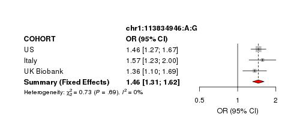

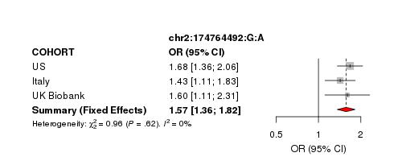

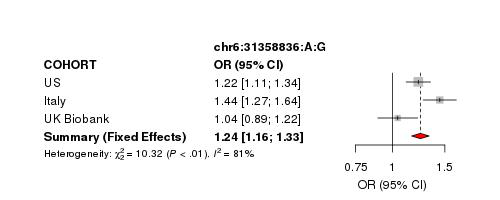

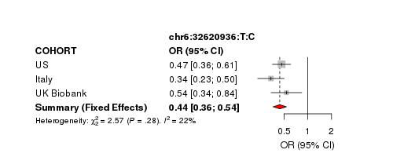

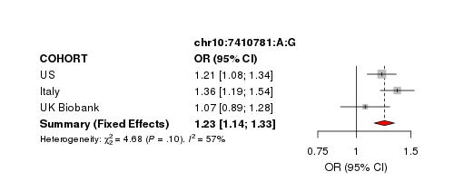

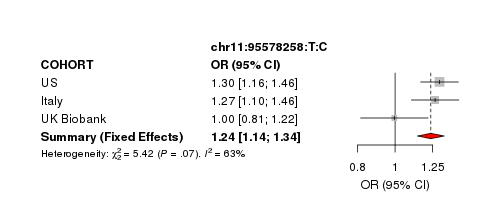

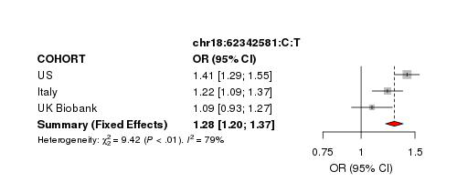

```python
from IPython.display import display
from PIL import Image

plot="ForestPlots/chr1_113834946_G_A.new.MG.forestplot.jpeg"
display(Image.open(plot))

plot="ForestPlots/chr2_174764492_G_A.new.MG.forestplot.jpeg"
display(Image.open(plot))

plot="ForestPlots/chr6_31358836_G_A.new.MG.forestplot.jpeg"
display(Image.open(plot))

plot="ForestPlots/chr6_32620936_T_C.new.MG.forestplot.jpeg"
display(Image.open(plot))

plot="ForestPlots/chr10_7410781_A_G.new.MG.forestplot.jpeg"
display(Image.open(plot))

plot="ForestPlots/chr11_95578258_T_C.new.MG.forestplot.jpeg"
display(Image.open(plot))

plot="ForestPlots/chr18_62342581_T_C.new.MG.forestplot.jpeg"
display(Image.open(plot))
```